# Labor force market in Puerto Rico and U.S. mainland

##### The data I am using in this research is ACS (American Community Surveys) 2016 data, From the data, I found that the labor force participation rate in Puerto Rico(0.58) is far lower than it in the U.S. mainland(0.75).

##### To find out the reason that caused such a huge difference, I took age and disability as two main variables and tried to explore the relationship between these variables and the labor force statue.

##### First of all, I want to say “thank you” to professor Magallanes and Isabella, I would’t be able to finish this simple project without your generous help.

# Get the data from Github

```r
data0URL <- "https://raw.githubusercontent.com/TianXinyu/FinalProject/master/usa_00003.csv"
data0 <- read.csv(data0URL)
```

# See the structure of the data

```r
class(data0)
```

```
## [1] "data.frame"
```

```r
names(data0)
```

```
##  [1] "DATANUM"  "AGE"      "LABFORCE" "DIFFREM"  "DIFFPHYS" "DIFFMOB"
##  [7] "DIFFCARE" "DIFFSENS" "DIFFEYE"  "DIFFHEAR"
```

```r
str(data0)
```

```
## 'data.frame':    3186711 obs. of  10 variables:
##  $ DATANUM : int  1 1 1 1 1 1 1 1 1 1 ...
##  $ AGE     : int  84 84 78 46 52 20 16 66 68 64 ...
##  $ LABFORCE: int  1 1 2 2 1 1 1 1 1 2 ...
##  $ DIFFREM : int  1 1 1 1 1 1 1 1 1 1 ...
##  $ DIFFPHYS: int  1 1 1 1 1 1 1 1 1 1 ...
##  $ DIFFMOB : int  1 1 1 1 1 1 1 1 1 1 ...
##  $ DIFFCARE: int  1 1 1 1 1 1 1 1 1 1 ...
##  $ DIFFSENS: int  1 1 1 1 1 1 1 1 1 1 ...
##  $ DIFFEYE : int  1 1 1 1 1 1 1 1 1 1 ...
##  $ DIFFHEAR: int  1 1 1 1 1 1 1 1 1 1 ...
```

# Clean the dataset

## 1. Make age a numerical variable

```r
data0$AGE=as.numeric(data0$AGE)
data0$DATANUM=as.numeric(data0$DATANUM)
str(data0$AGE)
```

```
##  num [1:3186711] 84 84 78 46 52 20 16 66 68 64 ...
```

```r
str(data0$DATANUM)
```

```
##  num [1:3186711] 1 1 1 1 1 1 1 1 1 1 ...
```

## 2. Keep people from 25-65

```r
data0=data0[data0$AGE>=25 & data0$AGE<=65, ]
str(data0)
```

```
## 'data.frame':    1685484 obs. of  10 variables:
##  $ DATANUM : num  1 1 1 1 1 1 1 1 1 1 ...
##  $ AGE     : num  46 52 64 63 25 35 26 25 37 36 ...
##  $ LABFORCE: int  2 1 2 1 2 2 2 2 2 2 ...
##  $ DIFFREM : int  1 1 1 1 1 1 1 1 1 1 ...
##  $ DIFFPHYS: int  1 1 1 1 1 1 1 1 2 1 ...
##  $ DIFFMOB : int  1 1 1 1 1 1 1 1 1 1 ...
##  $ DIFFCARE: int  1 1 1 1 1 1 1 1 1 1 ...
##  $ DIFFSENS: int  1 1 1 1 1 1 1 1 1 1 ...
##  $ DIFFEYE : int  1 1 1 1 1 1 1 1 1 1 ...
##  $ DIFFHEAR: int  1 1 1 1 1 1 1 1 1 1 ...
```

## 3. Clean all the missing datas in labor force, 0 is not in lbfc, 1 is in lbfc

```r
data0$LABFORCE=as.numeric(data0$LABFORCE)
data0$lbfc[data0$LABFORCE==1] <- 0
data0$lbfc[data0$LABFORCE==2] <- 1
str(data0)
```

```
## 'data.frame':    1685484 obs. of  11 variables:
##  $ DATANUM : num  1 1 1 1 1 1 1 1 1 1 ...
##  $ AGE     : num  46 52 64 63 25 35 26 25 37 36 ...
##  $ LABFORCE: num  2 1 2 1 2 2 2 2 2 2 ...
##  $ DIFFREM : int  1 1 1 1 1 1 1 1 1 1 ...
##  $ DIFFPHYS: int  1 1 1 1 1 1 1 1 2 1 ...
##  $ DIFFMOB : int  1 1 1 1 1 1 1 1 1 1 ...
##  $ DIFFCARE: int  1 1 1 1 1 1 1 1 1 1 ...
##  $ DIFFSENS: int  1 1 1 1 1 1 1 1 1 1 ...
##  $ DIFFEYE : int  1 1 1 1 1 1 1 1 1 1 ...
##  $ DIFFHEAR: int  1 1 1 1 1 1 1 1 1 1 ...
##  $ lbfc    : num  1 0 1 0 1 1 1 1 1 1 ...
```

## 4. Combine the diseases column together, get a new veriable(column), o is healthy, 1 is disabled

```r
Disable <- rep_len(0, length.out=nrow(data0))
data0 <- cbind(data0, Disable)
data0$Disable <- data0$Disable[data0$DIFFPHYS==1 & data0$DIFFCARE==1 & data0$DIFFMOB==1 & data0$DIFFSENS==1 & data0$DIFFEYE==1 & data0$DIFFHEAR==1] <-0
data0$Disable[data0$DIFFPHYS==2 | data0$DIFFCARE==2 | data0$DIFFMOB==2 |  data0$DIFFSENS==2 | data0$DIFFEYE==2 |  data0$DIFFHEAR==2] <-1
str(data0)
```

```
## 'data.frame':    1685484 obs. of  12 variables:
##  $ DATANUM : num  1 1 1 1 1 1 1 1 1 1 ...
##  $ AGE     : num  46 52 64 63 25 35 26 25 37 36 ...
##  $ LABFORCE: num  2 1 2 1 2 2 2 2 2 2 ...
##  $ DIFFREM : int  1 1 1 1 1 1 1 1 1 1 ...
##  $ DIFFPHYS: int  1 1 1 1 1 1 1 1 2 1 ...
##  $ DIFFMOB : int  1 1 1 1 1 1 1 1 1 1 ...
##  $ DIFFCARE: int  1 1 1 1 1 1 1 1 1 1 ...
##  $ DIFFSENS: int  1 1 1 1 1 1 1 1 1 1 ...
##  $ DIFFEYE : int  1 1 1 1 1 1 1 1 1 1 ...
##  $ DIFFHEAR: int  1 1 1 1 1 1 1 1 1 1 ...
##  $ lbfc    : num  1 0 1 0 1 1 1 1 1 1 ...
##  $ Disable : num  0 0 0 0 0 0 0 0 1 0 ...
```

# Get a new dataframe after cleaning

```r
data1 <- data0[,c('DATANUM','AGE','lbfc','Disable')]
str(data1)
```

```
## 'data.frame':    1685484 obs. of  4 variables:
##  $ DATANUM: num  1 1 1 1 1 1 1 1 1 1 ...
##  $ AGE    : num  46 52 64 63 25 35 26 25 37 36 ...
##  $ lbfc   : num  1 0 1 0 1 1 1 1 1 1 ...
##  $ Disable: num  0 0 0 0 0 0 0 0 1 0 ...
```

# Seperate the data into US data and PR data

```r
prdata <- data1[data1$DATANUM==2,]
str(prdata)
```

```
## 'data.frame':    15155 obs. of  4 variables:
##  $ DATANUM: num  2 2 2 2 2 2 2 2 2 2 ...
##  $ AGE    : num  32 62 49 51 45 47 60 41 58 36 ...
##  $ lbfc   : num  1 0 0 1 0 1 0 0 1 0 ...
##  $ Disable: num  0 0 0 0 1 0 0 0 0 1 ...
```

```r
usdata <- data1[data1$DATANUM==1,]
str(usdata)
```

```
## 'data.frame':    1670329 obs. of  4 variables:
##  $ DATANUM: num  1 1 1 1 1 1 1 1 1 1 ...
##  $ AGE    : num  46 52 64 63 25 35 26 25 37 36 ...
##  $ lbfc   : num  1 0 1 0 1 1 1 1 1 1 ...
##  $ Disable: num  0 0 0 0 0 0 0 0 1 0 ...
```

# Use probiblity table to see the labor force participation rate in PR and US

```r
prop.table(table(prdata$lbfc))
```

```
##
##         0         1
## 0.4150445 0.5849555
```

```r
prop.table(table(usdata$lbfc))
```

```
##
##         0         1
## 0.2490797 0.7509203
```

# Explore the relationship between lbfc and age.

## 1. Use boxplot to show the average age of both lbfc statues in PR

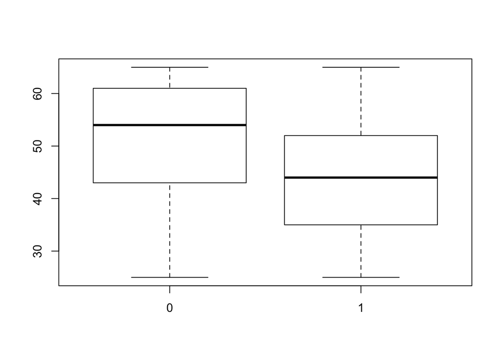

```r
boxplot(prdata$AGE~prdata$lbfc)
```

## 2. Sepret age into Y (young25-45) and O(old,45-65)

```r
prY <- prdata[prdata$AGE<=45,]
prO <- prdata[prdata$AGE>45,]
usY <- usdata[usdata$AGE<=45,]
usO <- usdata[usdata$AGE>45,]
```

## 3. Compare the difference between young people

```r
prop.table(table(prY$lbfc))
```

```
##
##         0         1
## 0.2731278 0.7268722
```

```r
prop.table(table(usY$lbfc))
```

```
##
##        0        1
## 0.187106 0.812894
```

## 4. Compare the difference between old people

```r
prop.table(table(prO$lbfc))
```

```
##
##         0         1
## 0.5308568 0.4691432
```

```r
prop.table(table(usO$lbfc))
```

```
##
##         0         1
## 0.3036018 0.6963982
```

# Explore the relationship between lbfc and disability

## 1. Use probiblity table to see the disability rate in PR and US

```r
prop.table(table(prdata$Disable))
```

```
##
##         0         1
## 0.8140548 0.1859452
```

```r
prop.table(table(usdata$Disable))
```

```
##
##         0         1
## 0.8883412 0.1116588
```

## 2. Use boxplot to show the average age of both health statues in PR

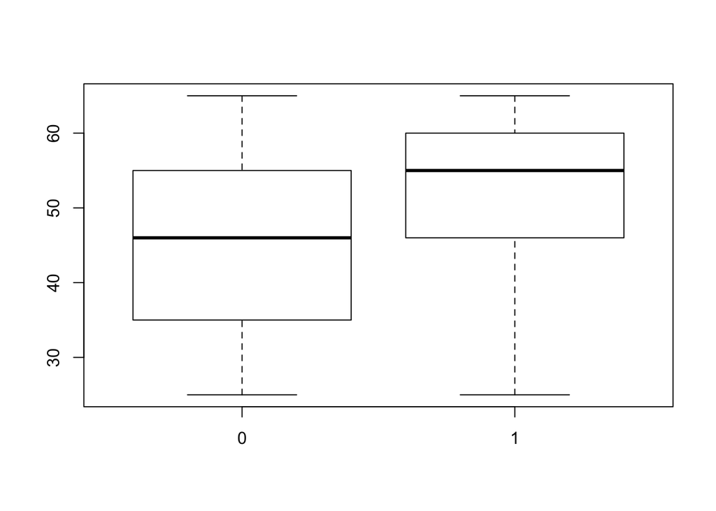

```r
boxplot(prdata$AGE~prdata$Disable)
```

## 3. For people who are disabled, how many of them are in labor force

```r
prdis <- prdata[prdata$Disable==1,]
usdis <- usdata[usdata$Disable==1,]
prop.table(table(prdis$lbfc))
```

```
##
##         0         1
## 0.7448545 0.2551455
```

```r
prop.table(table(usdis$lbfc))
```

```
##
##         0         1
## 0.6405175 0.3594825
```

# Use regression analysis to confirm the relationship between age and disability.

## 1. PR

```r
prdata$Disable=as.factor(prdata$Disable)
mod=glm(lbfc~.,data=prdata,family = 'binomial')
summary(mod)
```

```
##
## Call:
## glm(formula = lbfc ~ ., family = "binomial", data = prdata)
##
## Deviance Residuals:
##     Min       1Q   Median       3Q      Max
## -1.9568  -1.1004   0.6347   0.9232   1.9645
##
## Coefficients: (1 not defined because of singularities)
##              Estimate Std. Error z value Pr(>|z|)
## (Intercept)  3.030708   0.079965   37.90   <2e-16 ***
## DATANUM            NA         NA      NA       NA
## AGE         -0.051026   0.001633  -31.25   <2e-16 ***
## Disable1    -1.486812   0.048826  -30.45   <2e-16 ***
## ---
## Signif. codes:  0 '***' 0.001 '**' 0.01 '*' 0.05 '.' 0.1 ' ' 1
##
## (Dispersion parameter for binomial family taken to be 1)
##
##     Null deviance: 20570  on 15154  degrees of freedom
## Residual deviance: 17961  on 15152  degrees of freedom
## AIC: 17967
##
## Number of Fisher Scoring iterations: 4
```

## 2. US

```r
usdata$Disable=as.factor(usdata$Disable)
mod1=glm(lbfc~.,data=usdata,family = 'binomial')
summary(mod1)
```

```
##
## Call:
## glm(formula = lbfc ~ ., family = "binomial", data = usdata)
##
## Deviance Residuals:
##     Min       1Q   Median       3Q      Max
## -2.0673   0.5012   0.6052   0.7263   1.6103
##
## Coefficients: (1 not defined because of singularities)
##               Estimate Std. Error z value Pr(>|z|)
## (Intercept)  2.7374885  0.0082233   332.9   <2e-16 ***
## DATANUM             NA         NA      NA       NA
## AGE         -0.0290491  0.0001669  -174.0   <2e-16 ***
## Disable1    -1.8262534  0.0053308  -342.6   <2e-16 ***
## ---
## Signif. codes:  0 '***' 0.001 '**' 0.01 '*' 0.05 '.' 0.1 ' ' 1
##
## (Dispersion parameter for binomial family taken to be 1)
##
##     Null deviance: 1875184  on 1670328  degrees of freedom
## Residual deviance: 1696930  on 1670326  degrees of freedom
## AIC: 1696936
##
## Number of Fisher Scoring iterations: 4
```